# Come si assegna un giro a una lettura

I passi di `scegli_giro()`, con esempi calcolati dal codice

Data di Pubblicazione

30/10/2026

Documento scritto per spiegare, a chi non legge il codice, come una lettura riceve il suo giro. Il giro dà alla lettura il servizio atteso e il comune del giro, e da lì vengono la coerenza dei servizi e quella dei comuni. Il calendario dice che cosa era *previsto*, non che cosa è successo: per questo l’associazione è una serie di regole, dalla più sicura alla meno sicura, e una lettura che non ne soddisfa nessuna resta **senza giro**, invece di prenderne uno a caso.

# I dati di partenza

- **Letture**, con mezzo, data e ora, comune e posizione.
- **Giri pianificati**: mezzo, giorno, ora di inizio e di fine, servizio, comune, codice del giro.
- **Giri non pianificati**: mezzo, giorno, servizio, comune, codice del giro. Non hanno orari: non si sa quando iniziano e finiscono.
- **Giri aggiunti a mano**: quelli che si sa essere stati compiuti (da un consuntivo) ma che il calendario estratto non ha. Hanno tutti i campi dei giri pianificati e si rimettono tra i pianificati a ogni preparazione (vedi più sotto).

**Regola di base.** Una lettura può avere solo un giro dello *stesso mezzo* (matricola) e dello *stesso giorno*. Mai di un altro mezzo o di un altro giorno. I codici dei giri non pianificati hanno la stessa logica di quelli dei pianificati (un servizio in un comune) e possono coincidere con quelli di un pianificato di un altro giorno. I comuni si confrontano senza badare a maiuscole, accenti e apostrofi.

# I passi

La lettura attraversa i passi nell’ordine. Il primo che vale le dà il giro e gli altri non la vedono più.

[interactive chart not shown]

[output not shown]

I nomi in codice sono quelli che compaiono nel messaggio della pipeline («Giro associato alle letture: …»), con il numero di letture di ogni passo.

# L’orario, il ritardo e la tolleranza

L’orario di un giro pianificato non finisce a `ora_fine`. Una lettura del mezzo entro **30 minuti** dalla fine ne fa ancora parte e *diventa la nuova fine*; si va avanti finché la lettura seguente arriva entro lo stesso tempo dall’ultima. La catena si ferma all’inizio del pianificato seguente dello stesso mezzo. Fuori orario, il passo 7 accetta una lettura entro **60 minuti** dall’orario (contando la fine allungata), purché non abbia trovato un giro prima.

Il disegno qui sotto non è fatto a mano: è il risultato di `scegli_giro()` su un giro pianificato dalle 8 alle 12 e su sette letture dello stesso mezzo.

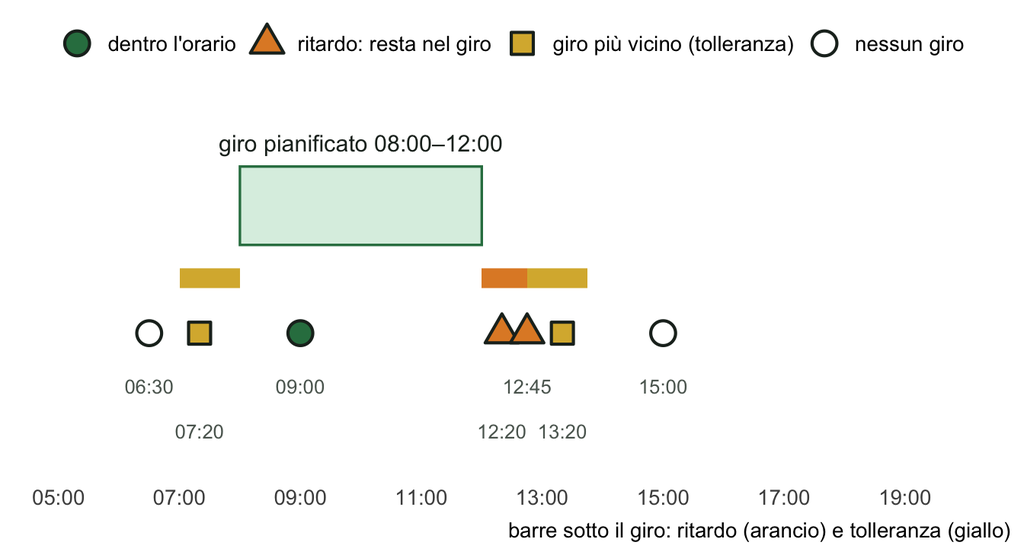

# I tratti

Un giro non pianificato non ha orari, ma le letture di un mezzo arrivano in sequenza. Se tra due letture passano più di **30 minuti**, comincia un tratto nuovo. In ogni tratto le letture già associate dai passi 1–4 «votano», e le orfane prendono il giro più frequente. È l’idea che, quando il mezzo lavora, le letture di seguito appartengono quasi sempre allo stesso giro.

L’esempio è calcolato da `scegli_giro()`: il mezzo ha due giri non pianificati, il vetro a Rosà e l’umido a Cassola. Le letture a Nove non sono in nessuno dei due comuni.

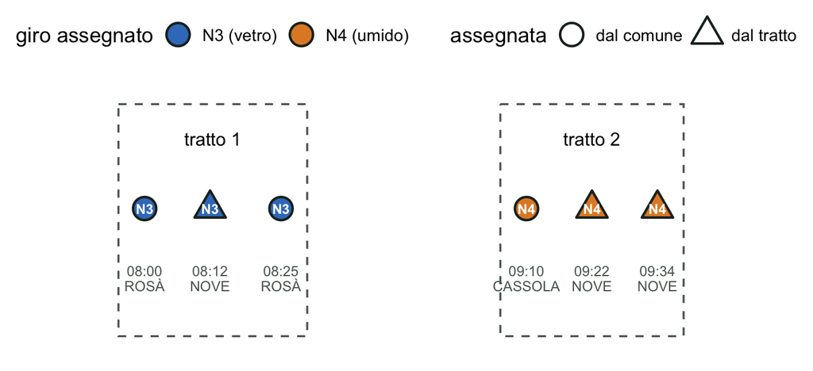

Le letture a Nove di ogni tratto prendono il giro delle altre letture dello stesso tratto (triangoli); quelle in un comune di un giro lo ricevono dal comune (cerchi).

# Un servizio solo, in più comuni

Se tutti i giri non pianificati del mezzo in quel giorno hanno lo stesso servizio, una lettura fuori dall’orario dei pianificati ha il servizio certo, anche se il comune non coincide con nessuno. Il giro (cioè il comune) è quello più vicino, misurato dal confine del comune con i confini della Regione. Le distanze qui sotto sono calcolate dal pacchetto.

[interactive chart not shown]

Il servizio (CARTA) è lo stesso nei due giri, quindi è certo; il giro è N1, il comune più vicino. Una lettura fuori da tutti i comuni dei giri resta «fuori giro»: il servizio è giusto, il comune no. Una lettura senza posizione non ha un comune più vicino: prende il giro solo se è l’unico candidato, altrimenti lo riceve dalle letture vicine dello stesso tratto, o resta senza giro.

# Un mezzo senza giri: il servizio dai censiti del tratto

Un mezzo che quel giorno non ha nessun giro nel calendario non ha un `id_giro` (servizio e comune) da cui prendere il servizio atteso. Il giro non si inventa: resta vuoto, insieme al suo comune. Si deduce solo il servizio, dai bidoni che il mezzo ha letto.

Il giro si approssima con il **tratto**: le letture di seguito, senza pause di oltre 30 minuti. Un mezzo non scarrabile raccoglie un rifiuto alla volta, quindi in un tratto il servizio è uno solo, mentre una pausa lunga può separare due servizi. Non si guarda il comune: serve il servizio, e un mezzo che attraversa due comuni con lo stesso servizio non va diviso.

[interactive chart not shown]

Il disegno è il risultato di `servizio_dei_censiti_del_mezzo()` su quattro tratti di un mezzo senza giri: ogni bidone conta una volta, anche se letto più volte.

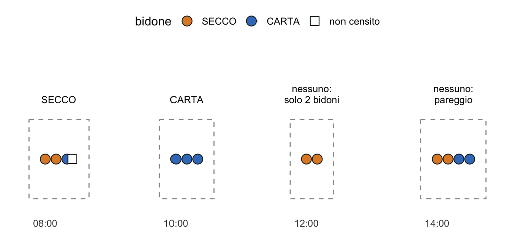

Il servizio atteso dà poi la coerenza del servizio (`SI` o `NO`) a ogni lettura. Un tratto con pochi bidoni darebbe quasi sempre `SI`, perché il servizio più frequente sarebbe quello del bidone stesso: per questo servono almeno 3 bidoni diversi.

# Giri aggiunti a mano

Il calendario estratto può non avere un giro che si sa compiuto (per esempio da un consuntivo). I giri mancanti si scrivono a mano in un file, `data-raw/origine/giri_aggiunti.csv`, che l’estrazione non tocca: a ogni aggiornamento del calendario vengono rimessi tra i giri pianificati dalla preparazione, e non si perdono.

[interactive chart not shown]

Il file ha **tutte le colonne del calendario dei giri pianificati**, perché i dati del giro si ricavano dal consuntivo:

| Colonna | Contenuto |
| --- | --- |
| `data_giro` | giorno del giro, `AAAA-MM-GG` oppure `GG/MM/AAAA` |
| `ora_inizio`, `ora_fine` | orario del giro, `HH:MM` o `HH:MM:SS`, l’inizio prima della fine |
| `matricola_mezzo` | matricola del mezzo; gli zeri iniziali non contano (`0933` e `933` sono lo stesso mezzo) |
| `id_giro` | codice del giro; può restare vuoto |
| `eseguito` | `SI` o `NO`; può restare vuoto |
| `descrizione_servizio` | servizio del giro come nel calendario, per esempio `SECCO PAP`; un nome che la tabella di conversione non conosce ferma la preparazione |
| `comune_giro` | comune del giro |

Un giro aggiunto vale come ogni giro pianificato: ha gli orari, l’`id_giro` e la conferma, e le sue letture seguono gli stessi passi (prima di tutto, quelle nel suo orario e nel suo comune). Un giro che il calendario ha già (stesso giorno, mezzo, servizio e comune) non si aggiunge due volte; un messaggio della pipeline dice quanti giri sono nuovi e quanti già presenti, che si possono togliere dal file. L’esempio mostra una lettura di un mezzo che il calendario non ha, prima e dopo l’aggiunta di un giro.

| Calendario | Giro della lettura | Passo |
| --- | --- | --- |
| Estratto, senza il giro | nessun giro | — |
| Con il giro aggiunto a mano | SECCO PAP | giro pianificato, nell’orario e nel comune della lettura |

La matricola del file è `0933`, quella della lettura `933`: il confronto non guarda gli zeri iniziali.

# Soglie e dove cambiarle

| Soglia | Valore | Funzione |
| --- | --- | --- |
| Ritardo dopo la fine di un pianificato | 30 minuti | `ritardo_giro_minuti()` |
| Pausa che apre un tratto nuovo | 30 minuti (lo stesso ritardo) | `assegna_tratti()` |
| Tolleranza dall’orario di un pianificato | 60 minuti | `tolleranza_giro_minuti()` |
| Distanza massima del comune più vicino | 2 km | `soglia_comune_vicino_m()` |
| Bidoni censiti diversi in un tratto di un mezzo senza giri | 3 bidoni | `censiti_minimi_per_tratto()` |

# Scelte e limiti da conoscere

- **Nessun «primo del calendario».** Con più servizi non pianificati e nessun indizio la lettura resta senza giro, invece di prendere il primo giro dell’elenco (scelta del 23 ottobre 2026).
- **Il non pianificato vince nel suo comune.** Una lettura dentro l’orario di un pianificato, ma nel comune di un non pianificato (e non in quello del pianificato), va al non pianificato (scelta del 21 ottobre 2026).
- **Pareggi.** A parità di distanza o di voti tra servizi diversi non si assegna niente. A parità di giro dello stesso servizio vale il primo del calendario.
- **Un tratto può unire giri diversi.** Se due giri si susseguono senza pause, le orfane prendono il più frequente: è un’approssimazione.
- **Zone fuori tabella.** Un comune del giro che non è un comune servito (per esempio il Massiccio del Grappa) non ha confini: le distanze mancano, e il passo 6 non vale per quei giri.
- **Un mezzo senza giri non ha un giro inventato.** Si deduce solo il servizio atteso, dai bidoni censiti del tratto; giro, comune del giro e `id_giro` restano vuoti. Quel servizio viene dai bidoni letti dal mezzo, quindi non dimostra da solo che facesse quel giro. Se si sa che il giro c’è stato, si aggiunge a mano.
- **Giri aggiunti a mano.** Valgono come i giri pianificati, con i loro orari; si rimettono nel calendario a ogni preparazione e non cambiano il file estratto. L’`eseguito` del file entra nei controlli dei giri (un giro `SI` senza letture dell’antenna dà un avviso).
- **Niente turni a cavallo della mezzanotte** né pianificati sovrapposti dello stesso mezzo.

# Come verificare che l’associazione funzioni

I bidoni censiti vengono raccolti dal loro servizio. Per le loro letture, la quota con `coerenza_servizio` uguale a `SI` dice quanto è giusto il giro assegnato. Confrontando, per ogni passo, la quota di coerenti e quella di letture assegnate si vede dove l’associazione è più sicura e dove conviene stringere o allargare le soglie.

# Come si cambia

La logica sta in `scegli_giro()` e nelle funzioni accanto (`passi_associazione()`, `allunga_fine()`, `assegna_tratti()`, `servizio_dei_censiti_del_mezzo()`, `aggiungi_giri_a_mano()`) in `R/fct_preparazione_letture.R`, con i test in `tests/testthat/test-fct_preparazione_letture.R`. Quando un passo cambia, vanno aggiornati la tabella `passi` in questo file, il paragrafo «Associazione lettura-giro» di `CLAUDE.md` e il README, e il documento va ricompilato.